# Data Analysis with R

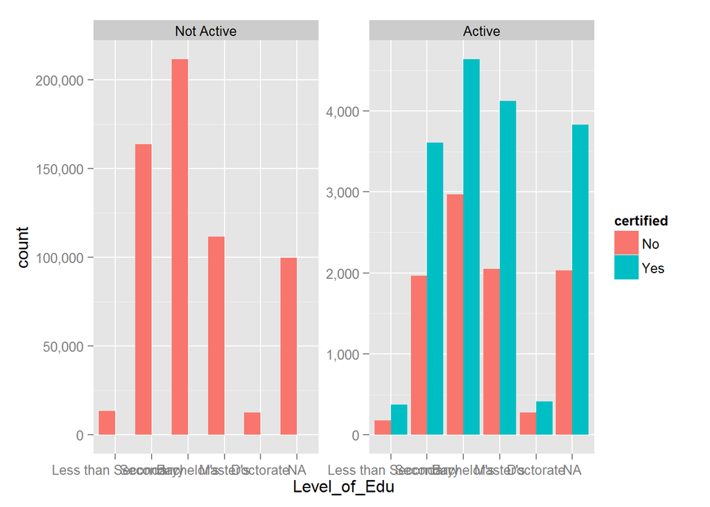

```r
# Active User/Certification/Edu
ggplot(subset(mooc_data, !is.na(Active_User)), aes(x=Level_of_Edu)) + geom_bar(aes(fill=certified), position="dodge") + facet_wrap(~Active_User, scales = "free") + scale_y_continuous(labels=comma)
```

CS50 is a pass/fail 0%/100% course. Average scores are very low when all registered students are included. It may be better to look at active students to get a better feel for student performance since so many registered but didn’t do anything in the course.

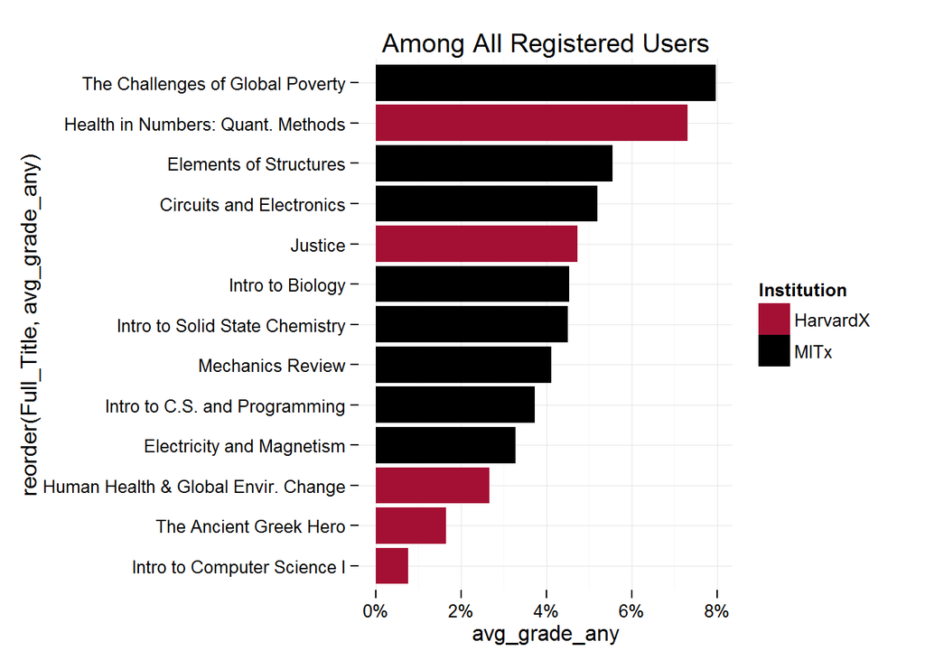

```r
mooc_summary_any <- mooc_data %>%
  filter(!is.na(grade)) %>%
  group_by(Full_Title, Institution) %>%
  summarise(avg_grade_any = mean(grade),
            n_any = n())

mooc_summary_active <- mooc_data %>%
  filter(!is.na(grade),
         Active_User == "Active") %>%
  group_by(Full_Title, Institution) %>%
  summarise(avg_grade_active = mean(grade),
            n_active = n())

mooc_summary <- left_join(mooc_summary_any, mooc_summary_active) %>%
  mutate(active_perc = n_active/n_any)

ggplot(mooc_summary, aes(x=reorder(Full_Title, avg_grade_any), y=avg_grade_any)) + geom_bar(aes(fill=Institution), stat="identity") + theme(axis.text.x=element_text(angle=90, size=9)) + scale_fill_manual(values = school_colors) + coord_flip() + theme_minimal() + scale_y_continuous(labels=percent) + ggtitle("Among All Registered Users")
```

What about among Active Users? Since Intro to CS1 is pass/fail, anyone who is active does not have 0.0 as a grade, and must have full 100% causing the average to be 100%.

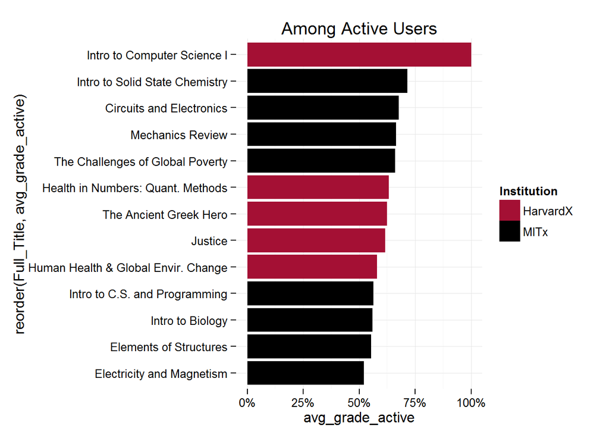

```r
ggplot(mooc_summary, aes(x=reorder(Full_Title, avg_grade_active), y=avg_grade_active)) + geom_bar(aes(fill=Institution), stat="identity") + theme(axis.text.x=element_text(angle=90, size=9)) + scale_fill_manual(values = school_colors) + coord_flip() + theme_minimal() + scale_y_continuous(labels=percent) + ggtitle("Among Active Users")
```

An interesting thing to note here is that the most popular course for registrations, Intro to Science Science I, had by far the lowest percentage of active users.

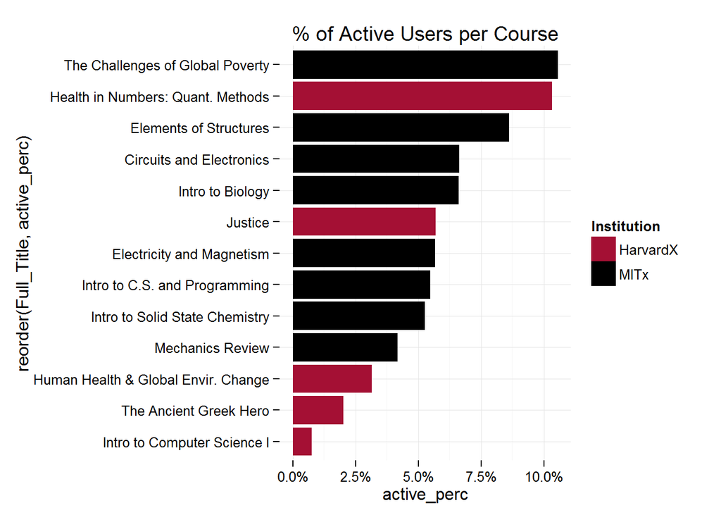

```r
ggplot(mooc_summary, aes(x=reorder(Full_Title, active_perc), y=active_perc)) + geom_bar(aes(fill=Institution), stat="identity") + theme(axis.text.x=element_text(angle=90, size=9)) + scale_fill_manual(values = school_colors) + coord_flip() + theme_minimal() + scale_y_continuous(labels=percent) + ggtitle("% of Active Users per Course")
```

Number of events and video plays don’t seems to have a very high correlation with overall grades.

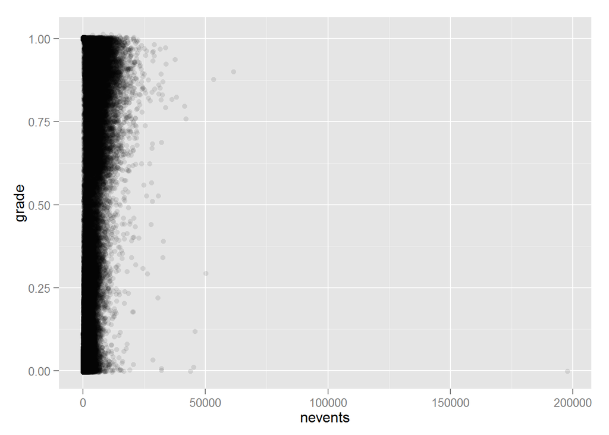

```r
ggplot(mooc_data, aes(x=nevents, y=grade)) + geom_jitter(alpha=1/10)
```

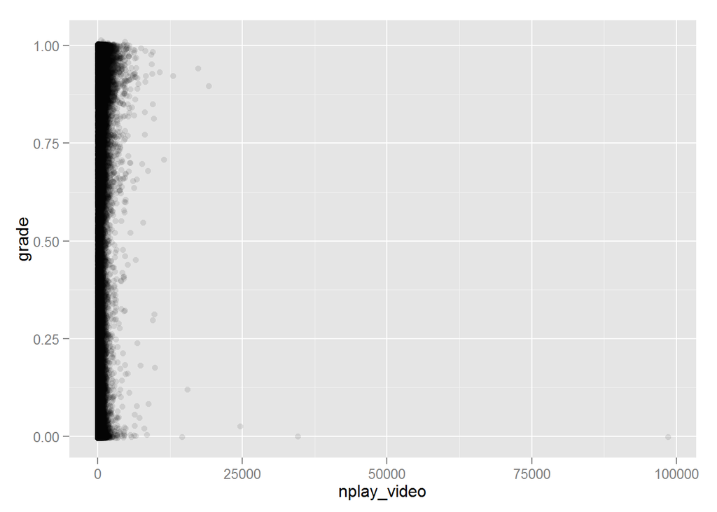

```r
ggplot(mooc_data, aes(x=nplay_video, y=grade)) + geom_jitter(alpha=1/10)
```

But number of unique days logged in and number of chapters viewed show some correlation.

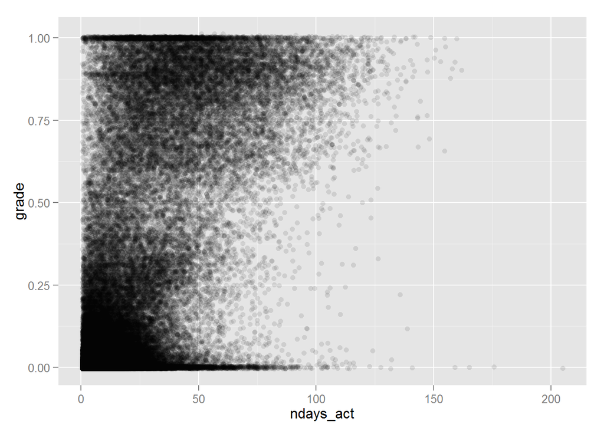

```r
ggplot(mooc_data, aes(x=ndays_act, y=grade)) + geom_jitter(alpha=1/10)
```

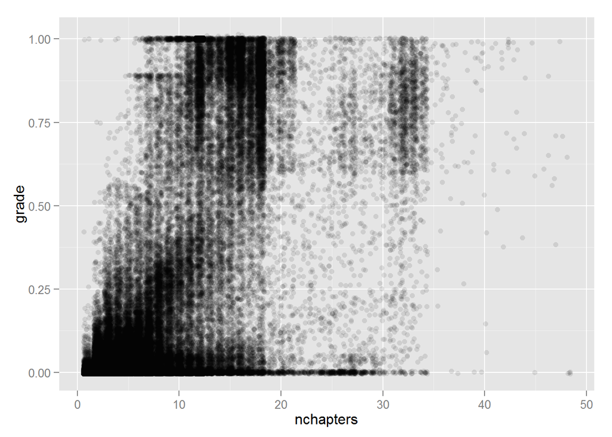

```r
ggplot(mooc_data, aes(x=nchapters, y=grade)) + geom_jitter(alpha=1/10)
```

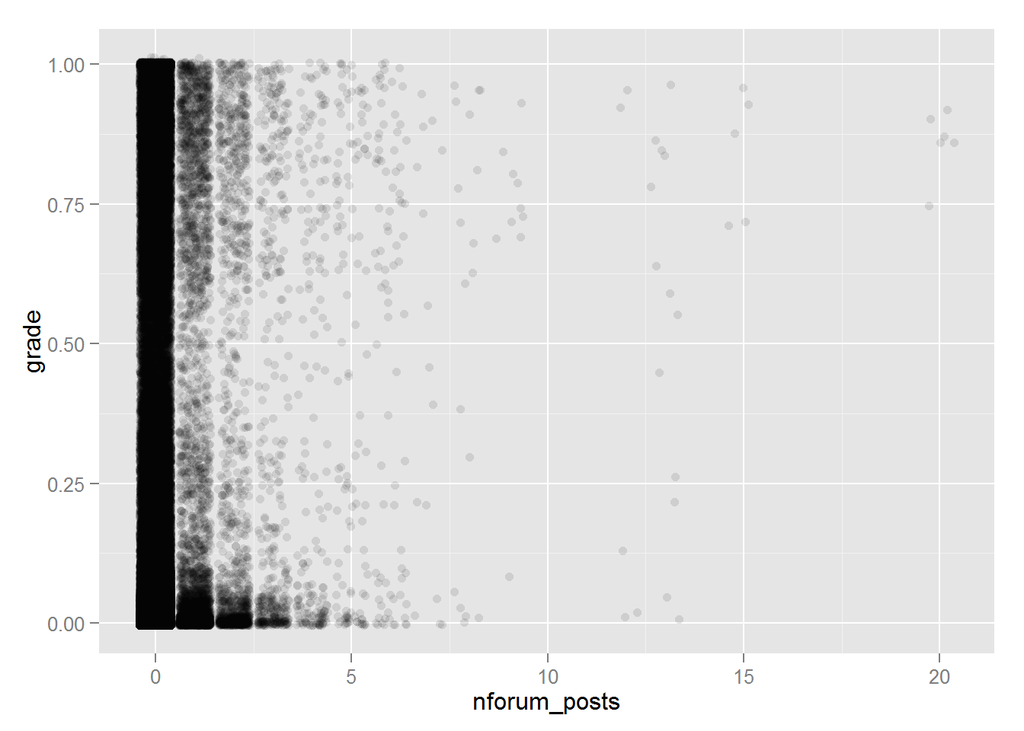

```r
ggplot(mooc_data, aes(x=nforum_posts, y=grade)) + geom_jitter(alpha=1/10)
```

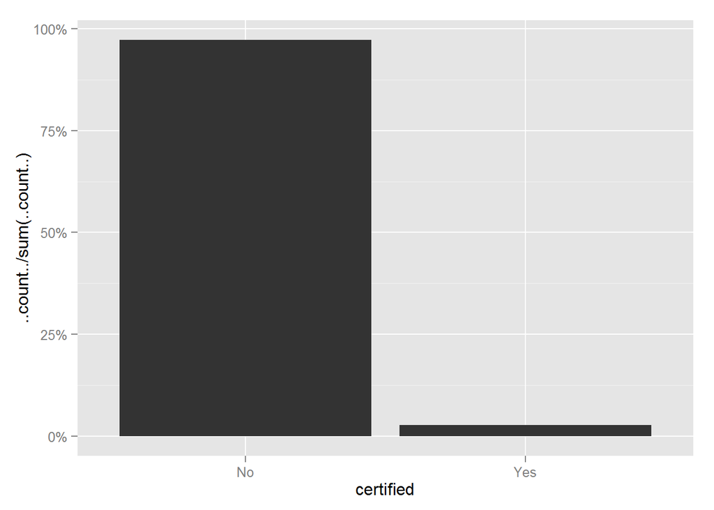

```r
# Certified percentages
ggplot(mooc_data, aes(x=certified, y=..count../sum(..count..))) + geom_bar() + scale_y_continuous(labels=percent)
```

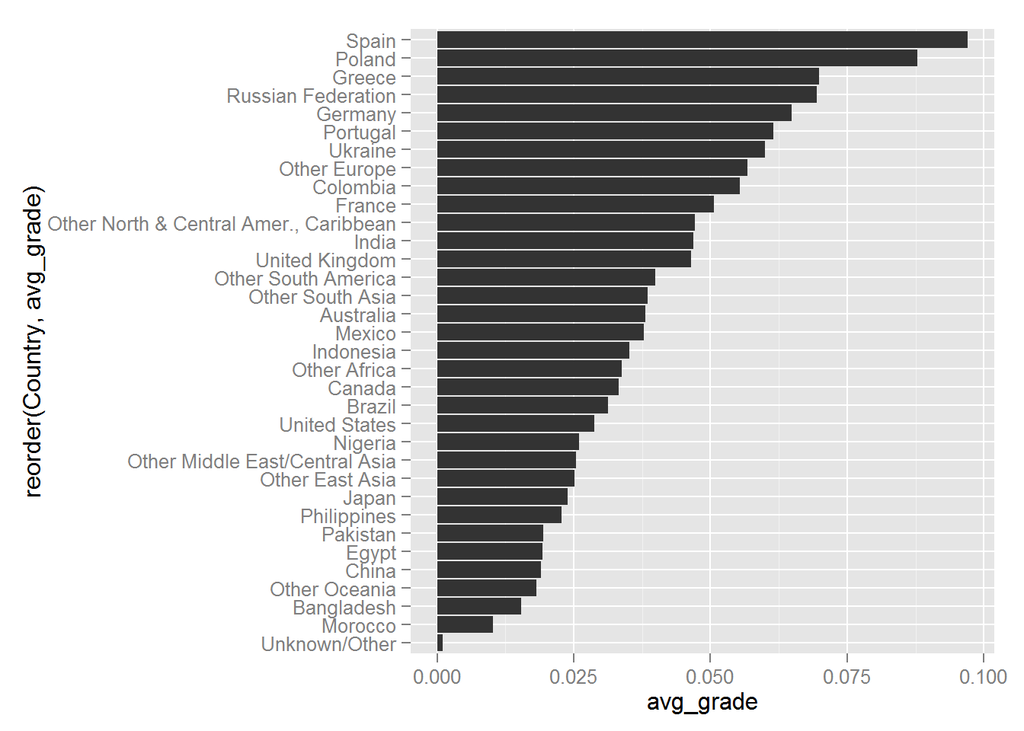

```r
# Countries

country_grade <- mooc_data %>%
  filter(!is.na(grade)) %>%
  group_by(Country) %>%
  summarise(avg_grade = mean(grade))
# Average grade

ggplot(country_grade, aes(x=reorder(Country, avg_grade), y=avg_grade)) + geom_bar(stat="identity") + coord_flip()
```

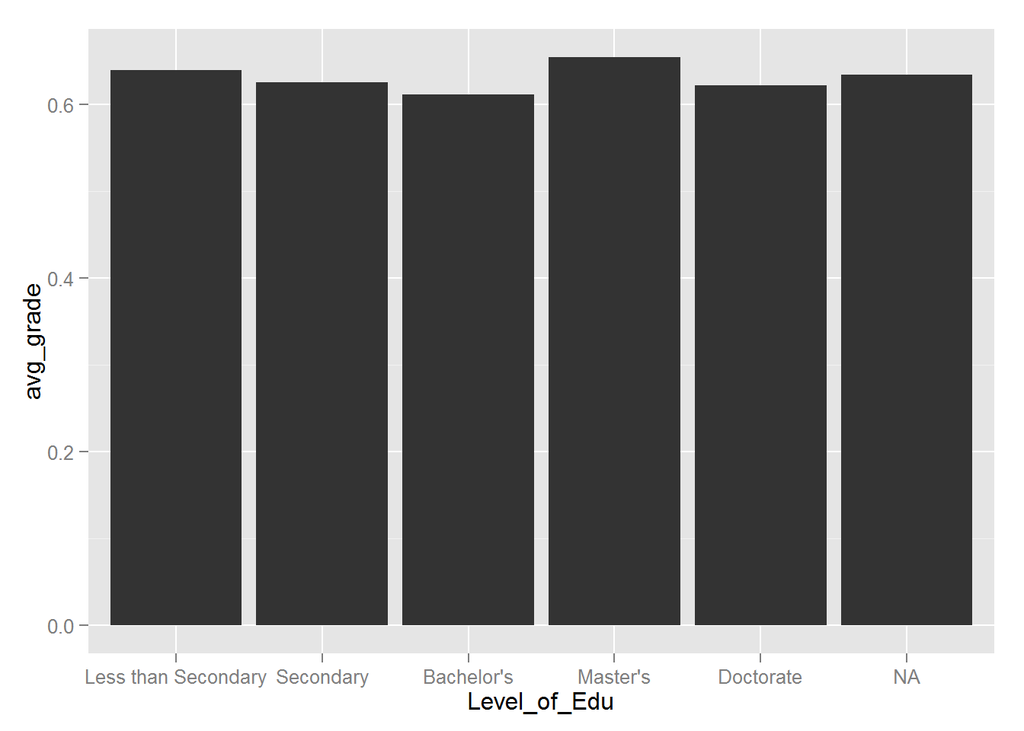

```r
# Education

# Among Active Users, there isn't much of a difference in final grades distributions
edu_grade <- mooc_data %>%
  filter(Active_User == "Active") %>%
  group_by(Level_of_Edu) %>%
  summarise(avg_grade = mean(grade))

ggplot(edu_grade, aes(x=Level_of_Edu, y=avg_grade)) + geom_bar(stat="identity")
```

```r
# There are so many student with 0.0 grade, that anything above is an outlier; 3rd quantile is still 0.0!
summary(mooc_data$grade)
```

```
##    Min. 1st Qu.  Median    Mean 3rd Qu.    Max.    NA's
##       0       0       0       0       0       1   57400
```

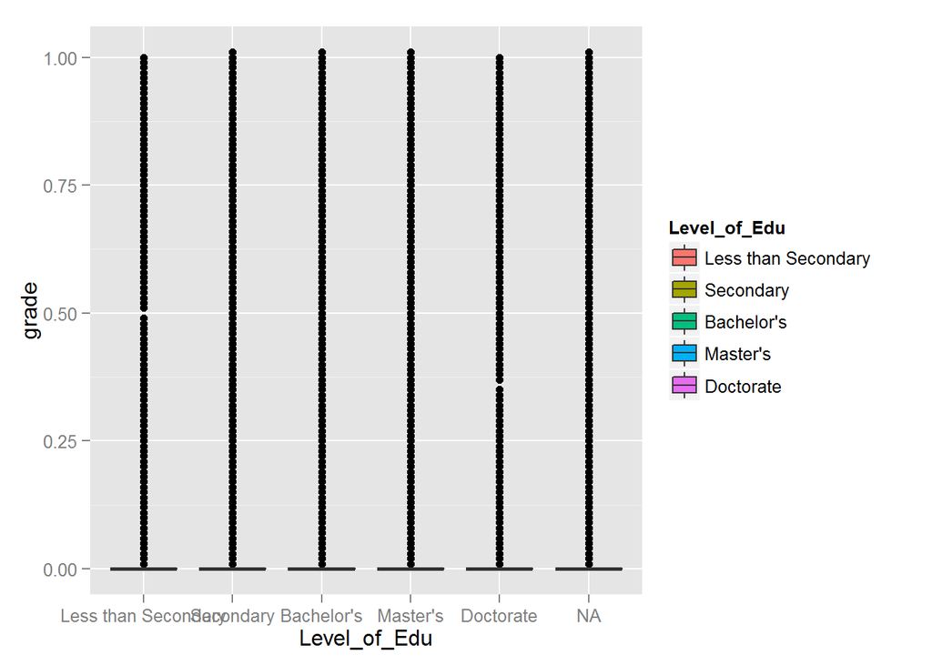

```r
ggplot(mooc_data, aes(x=Level_of_Edu, y=grade, fill=Level_of_Edu)) + geom_boxplot()
```

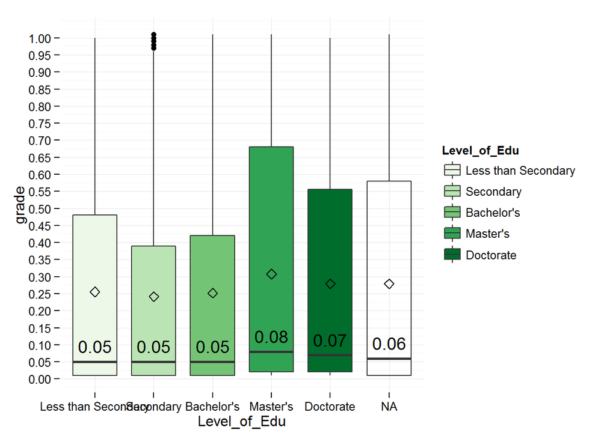

```r
# Just filtering out students with a grade of 0.0 shows the distributions better
ggplot(subset(mooc_data, grade > 0.0), aes(x=Level_of_Edu, y=grade, fill=Level_of_Edu)) +
  geom_boxplot() +
  scale_y_continuous(breaks=seq(0, 1, .05)) +
  scale_fill_brewer(type="seq", palette=5) +
  theme_minimal() +
  stat_summary(fun.y=median, colour="black", geom="text", show_guide = FALSE, vjust=-0.7,
               aes( label=round(..y.., digits=2))) +
  stat_summary(fun.y=mean, colour="black", geom="point", show_guide = FALSE, vjust=-0.7, shape=23, size=3)
```

```r
table(mooc_data$letter_grade)
```

```
##
##    [0,0.01] (0.01,0.49] (0.49,0.59] (0.59,0.69] (0.69,0.79] (0.79,0.89]
##      529284       35557        1631        2662        2994        4498
## (0.89,1.01]
##        7112
```

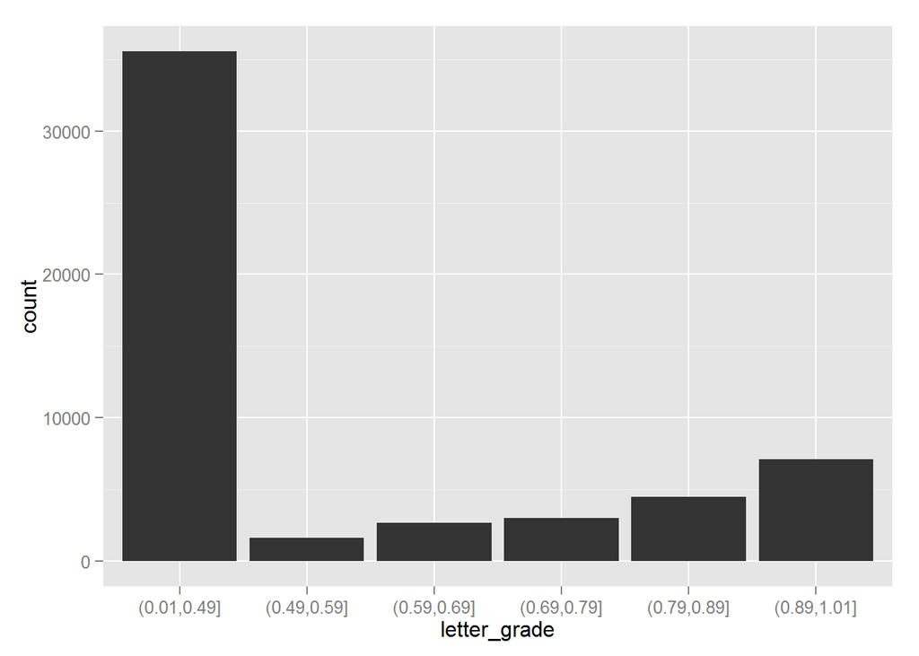

```r
ggplot(subset(mooc_data, letter_grade != "[0,0.01]"), aes(x=letter_grade)) + geom_histogram()
```

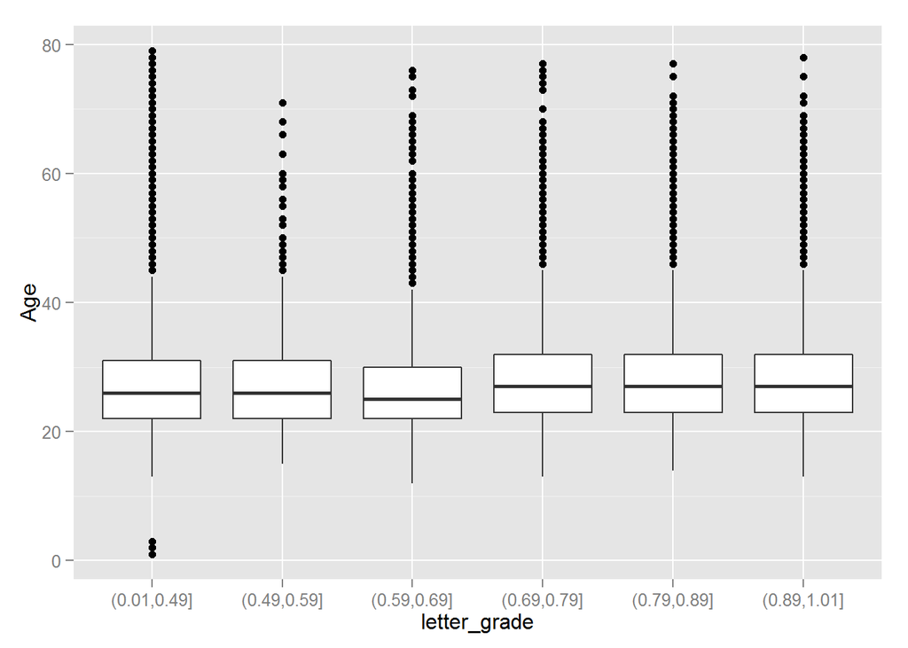

```r
ggplot(subset(mooc_data, letter_grade != "[0,0.01]"), aes(x=letter_grade, y=Age)) + geom_boxplot()
```

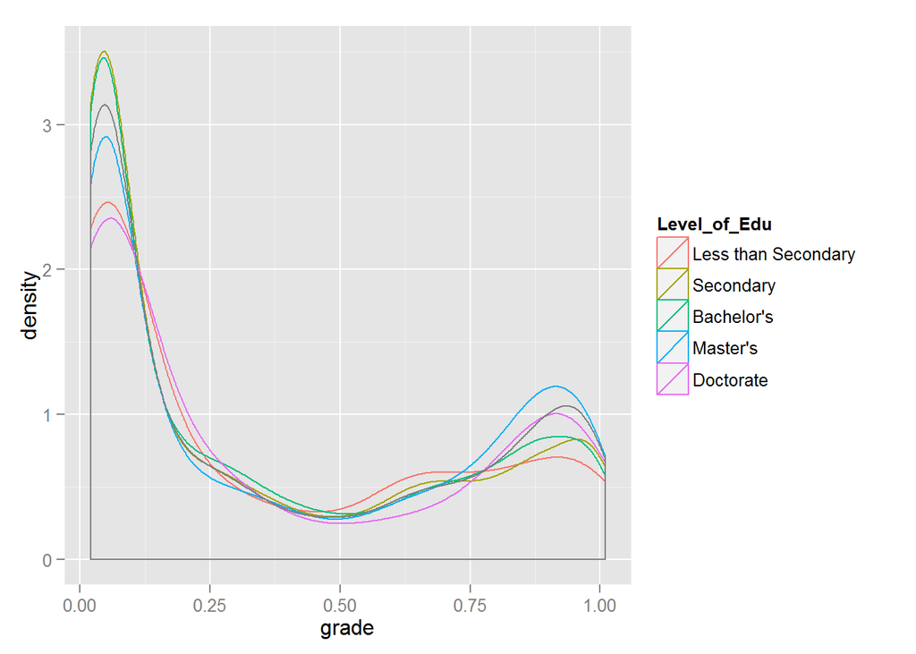

```r
ggplot(subset(mooc_data, letter_grade != "[0,0.01]"), aes(x=grade, color=Level_of_Edu)) + geom_density(position="dodge")
```

# Analysis

## Percentage Who Earned Completion Certificates

### How many students earned certificates?

Only 2.8% of registered students passed their respective courses.

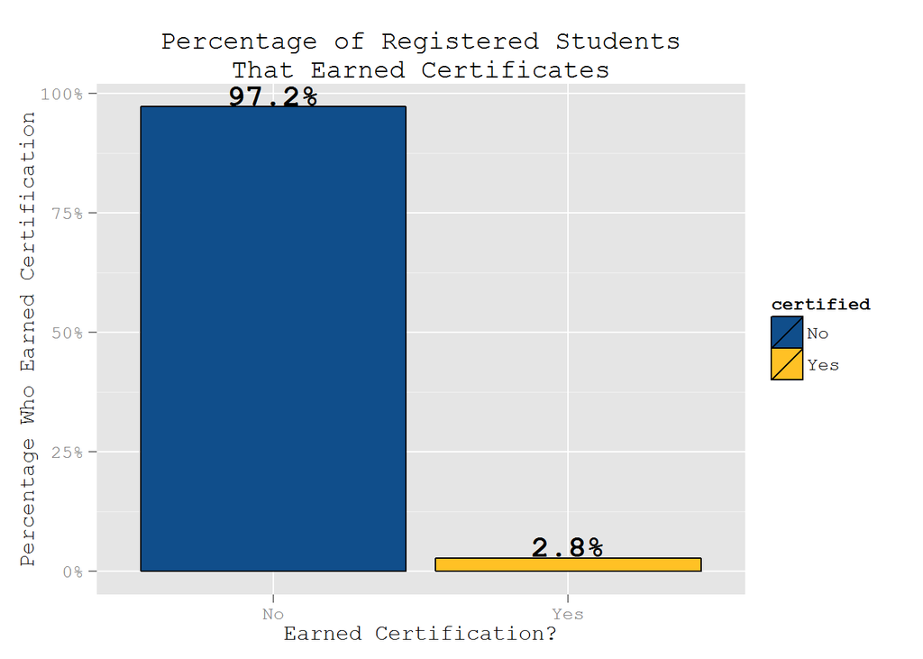

```r
cert <- mooc_data %>%
  filter(!is.na(certified)) %>%
  group_by(certified) %>%
  summarise(n=n()) %>%
  mutate(perc = n/sum(n))

ggplot(cert, aes(x=certified, y=perc, fill=certified)) +
  geom_histogram(stat="identity", color="black") +
  scale_y_continuous(labels=percent) +
  geom_text(aes(family="mono", fontface="bold", y=perc, label=paste(round(perc, 3)*100, "%", sep="")),
            color="black", size=6, vjust = -0.1) +
  scale_fill_manual(values=c("dodgerblue4", "goldenrod1")) +
  ggtitle("Percentage of Registered Students\nThat Earned Certificates") + xlab("Earned Certification?") + ylab("Percentage Who Earned Certification") +
  theme(text=element_text(family="mono"))
```

Female students had a slightly higher course completion percentage, but overall, there wasn’t a large difference in completion rate between the sexes.

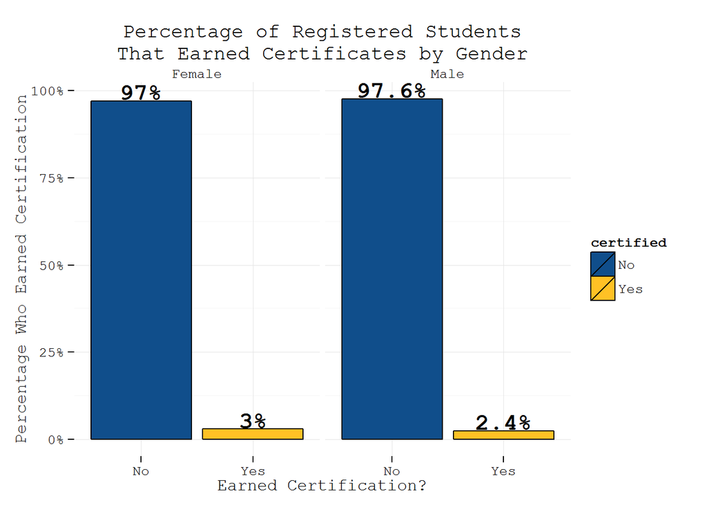

```r
mooc_gender <- mooc_data %>%
  filter(!is.na(gender),
         gender != "Other") %>%
  group_by(certified, gender) %>%
  summarise(n=n()) %>%
  group_by(gender) %>%
  mutate(percentage = n/sum(n))

ggplot(mooc_gender, aes(x=certified, y=percentage, fill=certified)) + geom_bar(stat="identity", color="black") +
  scale_y_continuous(labels=percent) + facet_wrap(~gender) +
  geom_text(aes(family="mono", fontface="bold", y=percentage, label=paste(round(percentage, 3)*100, "%", sep="")),
            color="black", size=6, vjust = -0.1) +
  theme_minimal() + ggtitle("Percentage of Registered Students\nThat Earned Certificates by Gender") +
  scale_fill_manual(values=c("dodgerblue4", "goldenrod1")) +
  xlab("Earned Certification?") + ylab("Percentage Who Earned Certification") +
  theme(text=element_text(family="mono"))
```

When it comes to student location, Spain and Poland lead the pack for earning certificates of completion.

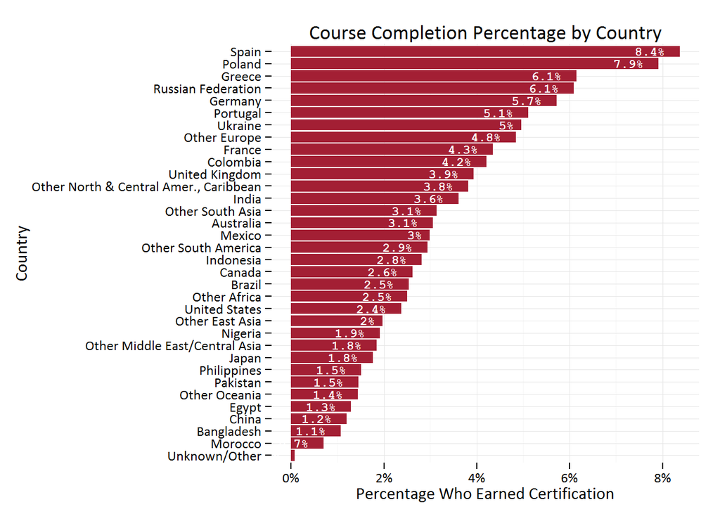

```r
country_cert <- mooc_data %>%
  group_by(Country, certified) %>%
  summarise(n = n()) %>%
  group_by(Country) %>%
  mutate(perc = n/sum(n))

ggplot(subset(country_cert, certified=="Yes"), aes(x=reorder(Country, perc), y=perc)) +
  geom_bar(stat="identity", fill="#A31F34") +
  coord_flip() +
  scale_y_continuous(labels = percent) +
  geom_text(aes(family="mono", fontface="bold", y=perc, label=paste(round(perc, 3)*100, "%", sep="")),
            color="white", size=3, hjust=1.5) +
  theme_minimal() + ggtitle("Course Completion Percentage by Country") +
  theme(text=element_text(family="Calibri")) + ylab("Percentage Who Earned Certification") + xlab("Country")
```

## Course Enrollment

### What are the most popular courses?

Introductory courses for Computer Science and Programming are by far the most popular courses.

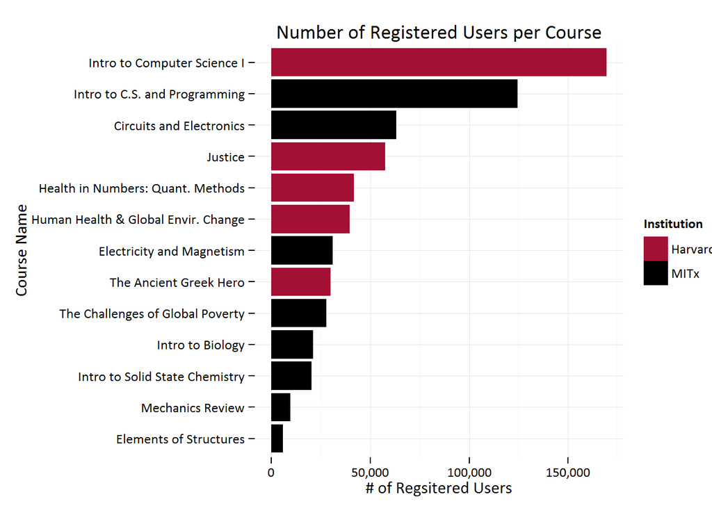

```r
mooc_pop <- mooc_data %>%
  group_by(Full_Title, Institution) %>%
  summarise(n = n())

ggplot(mooc_pop, aes(x=reorder(Full_Title, n), y=n, fill=Institution)) +
  geom_bar(stat="identity") +
  theme(axis.text.x=element_text(angle=90, size=9)) +
  scale_fill_manual(values = school_colors) +
  coord_flip() +
  theme_minimal() +
  scale_y_continuous(labels=comma) +
  ggtitle("Number of Registered Users per Course") + xlab("Course Name") + ylab("# of Regsitered Users") +
  theme(text=element_text(family="Calibri"))
```

Almost 3 times more males registered for courses than females.

But was there a difference in registered courses by gender?

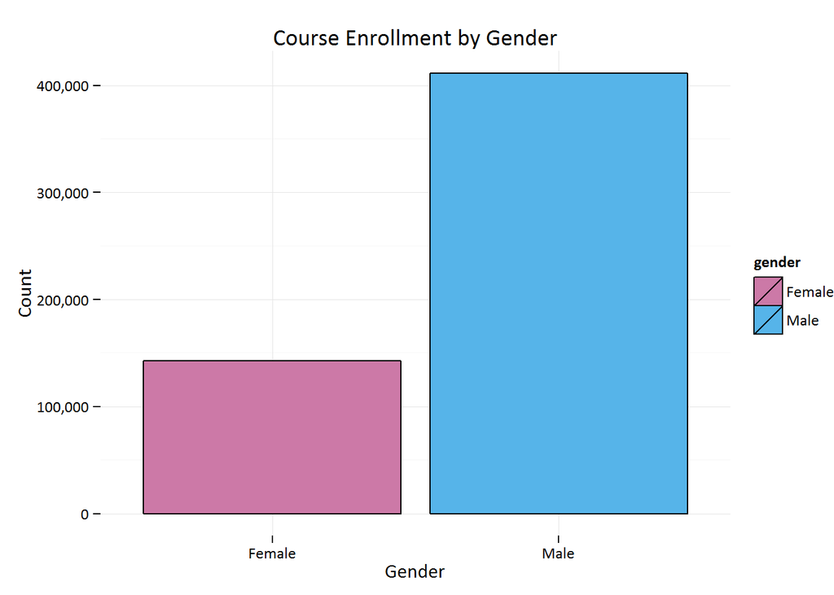

```r
ggplot(subset(mooc_data, (!is.na(gender) & gender != "Other")), aes(x=gender, fill=gender) ) +
  geom_bar(color="black") +
  theme_minimal() +
  scale_y_continuous(labels=comma) +
  scale_fill_manual(values=c("#CC79A7", "#56B4E9")) +
  ggtitle("Course Enrollment by Gender") + xlab("Gender") + ylab("Count") +
  theme(text=element_text(family="Calibri"))
```

The two most popular courses overall were also most popular for males.

Courses closer to the Humanities nearly identical gender ratios while hard sciences were male-dominated in course registrations.

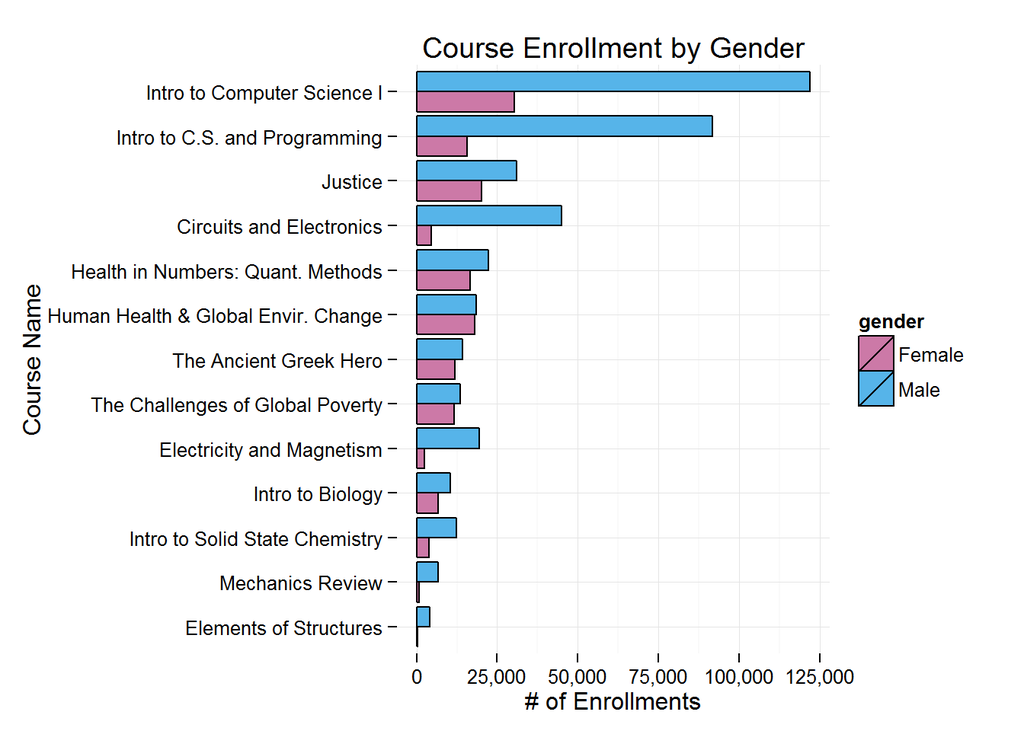

```r
gender_enroll <- mooc_data %>%
  filter(!is.na(gender),
         gender != "Other") %>%
  group_by(Full_Title, gender, Institution) %>%
  summarise(n = n())

ge1 <- ggplot(gender_enroll, aes(x=reorder(Full_Title, n), y=n, fill=gender) ) +
  geom_bar(stat="identity", position="dodge", color="black") +
  theme_minimal() +
  coord_flip() +
  scale_y_continuous(labels=comma) +
  scale_fill_manual(values=c("#CC79A7", "#56B4E9")) +
  ggtitle("Course Enrollment by Gender") + xlab("Course Name") + ylab("# of Enrollments")

ge1
```

# Age

## What are the age distributions like for students?

Most registered students were between 20 and 28, with quite a few older students in a right-tailed distribution.

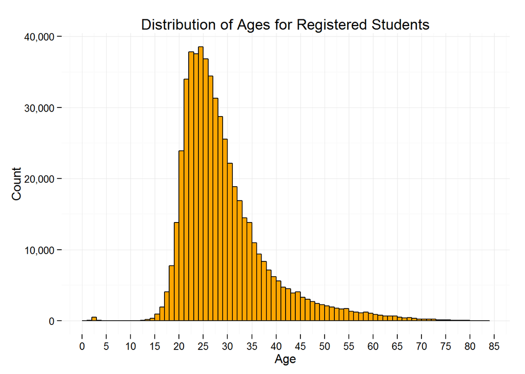

```r
ggplot(mooc_data, aes(x=Age)) +
  geom_bar(binwidth=1, fill="orange", color="black") +
  scale_x_continuous(breaks=seq(0, 85, 5)) +
  scale_y_continuous(labels=comma) +
  ggtitle("Distribution of Ages for Registered Students") + xlab("Age") + ylab("Count") +
  theme(text=element_text(family="Calibri")) +
  theme_minimal()
```

The U.S., Spain, Nigeria, and Japan had the oldest population of registered students while Morocco, Egypt, and India had the youngest populations of registered students.

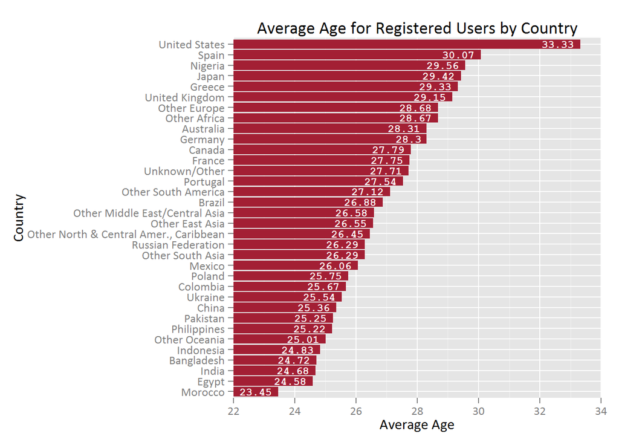

```r
country_age <- mooc_data %>%
  filter(!is.na(Age)) %>%
  group_by(Country) %>%
  summarise(avg_age = mean(Age))

ggplot(country_age, aes(x=reorder(Country, avg_age), y=avg_age)) +
  geom_bar(stat="identity", fill="#A31F34") +
  coord_flip(ylim=c(22, 34)) +
  geom_text(aes(family="mono", fontface="bold", y=avg_age,
                label=round(avg_age, 2)), color="white", size=3, hjust=1.2) +
  ggtitle("Average Age for Registered Users by Country") + xlab("Country") + ylab("Average Age") +
  theme(text=element_text(family="Calibri"))
```

# Education

Most students who register have a bachelor’s degree.

This remains true when filtering out only active users, although post-graduate degree percentages increase among active users.

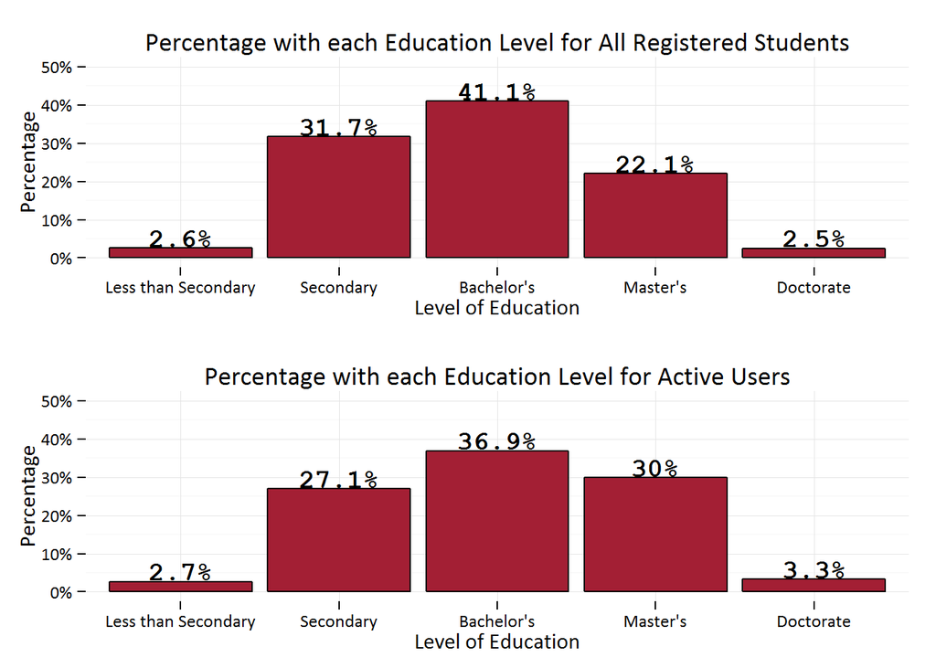

```r
edu <- mooc_data %>%
  filter(!is.na(Level_of_Edu)) %>%
  group_by(Level_of_Edu) %>%
  summarise(n=n()) %>%
  mutate(perc = n/sum(n))

e1 <- ggplot(edu, aes(x=Level_of_Edu, y=perc)) +
  geom_bar(stat="identity", fill="#A31F34", color="black") +
  scale_y_continuous(labels=percent, limits=c(0, 0.50)) +
  geom_text(aes(family="mono", fontface="bold", y=perc, label=paste(round(perc, 3)*100, "%", sep="")),
            color="black", size=5, vjust = -0.1)  +
  ggtitle("Percentage with each Education Level for All Registered Students") + ylab("Percentage") + xlab("Level of Education") +
  theme_minimal() +
  theme(text=element_text(family="Calibri"))

edu2 <- mooc_data %>%
  filter(!is.na(Level_of_Edu),
         Active_User == "Active") %>%
  group_by(Level_of_Edu) %>%
  summarise(n=n()) %>%
  mutate(perc = n/sum(n))

e2 <- ggplot(edu2, aes(x=Level_of_Edu, y=perc)) +
  geom_bar(stat="identity", fill="#A31F34", color="black") +
  scale_y_continuous(labels=percent, limits=c(0, 0.50)) +
  geom_text(aes(family="mono", fontface="bold", y=perc, label=paste(round(perc, 3)*100, "%", sep="")),
            color="black", size=5, vjust = -0.1) +
  ggtitle("Percentage with each Education Level for Active Users") + ylab("Percentage") + xlab("Level of Education") +
  theme_minimal() +
  theme(text=element_text(family="Calibri"))

grid.arrange(e1, e2)
```

Within each gender, males have noticeably higher percentages of registered students in Secondary school and while female have higher percentages of students with master’s degrees. This difference becomes more pronounced among active users.

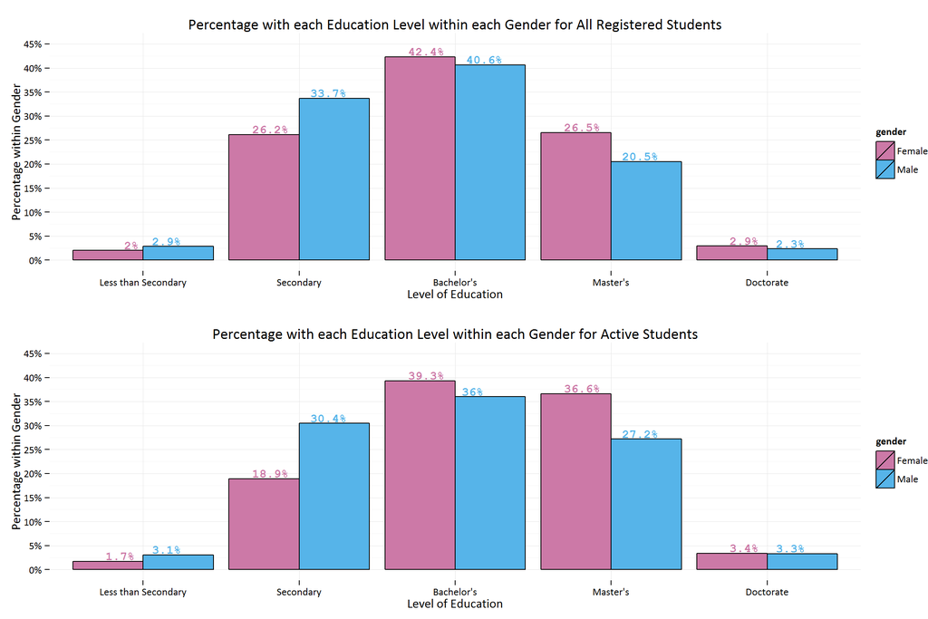

```r
mooc_edu1 <- mooc_data %>%
  filter(!is.na(Level_of_Edu),
         !is.na(gender),
         gender != "Other") %>%
  group_by(gender, Level_of_Edu) %>%
  summarize(n=n()) %>%
  mutate(perc = n/sum(n))

e3 <- ggplot(mooc_edu1, aes(x=Level_of_Edu, y=perc, fill=gender)) + geom_bar(stat="identity", position="dodge", color="black") +
  scale_fill_manual(values=c("#CC79A7", "#56B4E9")) +
  geom_text(data=subset(mooc_edu1, gender=="Female"),
            aes(family="mono", fontface="bold", y=perc, label=paste(round(perc, 3)*100, "%", sep="")),
            color="#CC79A7", size=4, vjust = -0.2, hjust=1.3) +
  geom_text(data=subset(mooc_edu1, gender=="Male"),
            aes(family="mono", fontface="bold", y=perc, label=paste(round(perc, 3)*100, "%", sep="")),
            color="#56B4E9", size=4, vjust = -0.2, hjust=-0.3) +
  scale_y_continuous(labels=percent, breaks=seq(0,0.45,0.05), limits=c(0, 0.45)) +
  theme_minimal() +
  theme(text=element_text(family="Calibri")) +
  ggtitle("Percentage with each Education Level within each Gender for All Registered Students") +
  ylab("Percentage within Gender") + xlab("Level of Education")

mooc_edu2 <- mooc_data %>%
  filter(!is.na(Level_of_Edu),
         !is.na(gender),
         Active_User == "Active",
         gender != "Other") %>%
  group_by(gender, Level_of_Edu) %>%
  summarize(n=n()) %>%
  mutate(perc = n/sum(n))

e4 <- ggplot(mooc_edu2, aes(x=Level_of_Edu, y=perc, fill=gender)) + geom_bar(stat="identity", position="dodge", color="black") +
  scale_fill_manual(values=c("#CC79A7", "#56B4E9")) +
  geom_text(data=subset(mooc_edu2, gender=="Female"),
            aes(family="mono", fontface="bold", y=perc, label=paste(round(perc, 3)*100, "%", sep="")),
            color="#CC79A7", size=4, vjust = -0.2, hjust=1.3) +
  geom_text(data=subset(mooc_edu2, gender=="Male"),
            aes(family="mono", fontface="bold", y=perc, label=paste(round(perc, 3)*100, "%", sep="")),
            color="#56B4E9", size=4, vjust = -0.2, hjust=-0.3) +
  scale_y_continuous(labels=percent, breaks=seq(0,0.45,0.05), limits=c(0, 0.45)) +
  theme_minimal() +
  theme(text=element_text(family="Calibri")) +
  ggtitle("Percentage with each Education Level within each Gender for Active Students") +
  ylab("Percentage within Gender") + xlab("Level of Education")

grid.arrange(e3, e4)
```

# Grades

And finally, we investigate how well do students do in the courses.

First, an age-old question: Who gets better grades - men or women?

Among active users, it’s very close to an outright tie with only 1.8% difference in overall average grades.

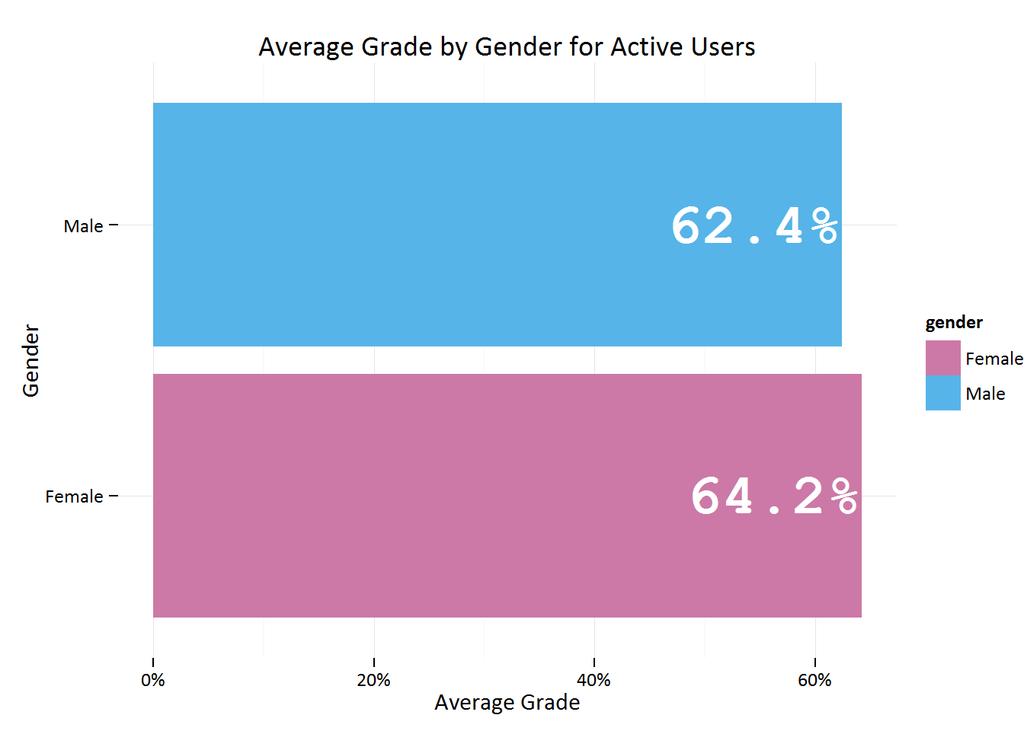

```r
mooc_gender_active_grade <- mooc_data %>%
  filter(!is.na(gender),
         gender != "Other",
         Active_User == "Active") %>%
  group_by(gender) %>%
  summarise(avg_grade = mean(grade, na.rm=TRUE),
            n=n())

ggplot(mooc_gender_active_grade, aes(x=gender)) + geom_bar(aes(fill=gender, y=avg_grade), stat="identity") +
  coord_flip() +
  scale_y_continuous(labels=percent) +
  geom_text(aes(family="mono", fontface="bold", y=avg_grade, label=paste(round(avg_grade, 3)*100, "%", sep="")),
            color="white", size=10, hjust=1) +
  ggtitle("Average Grade by Gender for Active Users") + ylab("Average Grade") + xlab("Gender") +
  scale_fill_manual(values=c("#CC79A7", "#56B4E9")) +
  theme_minimal() +
  theme(text=element_text(family="Calibri"))
```

But with different genders being drawn to different courses, how did grades differ between the different classes?

Women did slightly better in many of the classes that were dominated by male registrants. It also seems that the larger numbers of males passing Intro to CS I (100% pass/fail course) may have helped boost overall male grade % a bit.

We can also see that Electricity and Magnetism was the hardest course for active students.

Note: Again, Intro to CS I was pass/fail so the average grade for active users here is 100%.

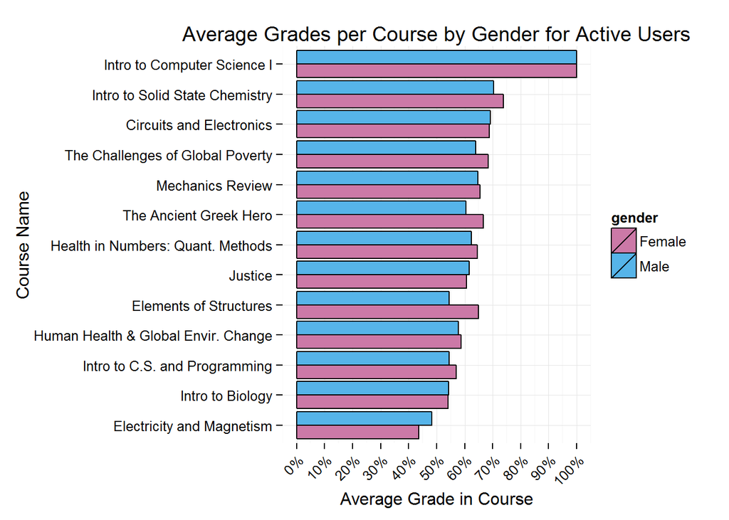

```r
mooc_gender_active <- mooc_data %>%
  filter(!is.na(gender),
         gender != "Other",
         Active_User == "Active") %>%
  group_by(Full_Title, gender, Institution) %>%
  summarise(avg_grade = mean(grade, na.rm=TRUE),
            n=n())

ge2 <- ggplot(mooc_gender_active, aes(x=reorder(Full_Title, avg_grade), y=avg_grade, fill=gender) ) +
  geom_bar(stat="identity", position="dodge", color="black") +
  theme_minimal() +
  coord_flip() +
  scale_y_continuous(labels=percent, breaks=seq(0, 1, 0.1)) +
  scale_fill_manual(values=c("#CC79A7", "#56B4E9")) +
  ggtitle("Average Grades per Course by Gender for Active Users") + xlab("Course Name") + ylab("Average Grade in Course") +
  theme(axis.text.x = element_text(angle = 45, hjust = 1))

ge2
```

Averages grades by age for active users stayed fairly consistent until around 50 years of age where average grades become erratic. This is probably due in part to the right-skew of the data causing there to be less data available for ages 50+.

We can see the min/max in the lighter bands of color, while the IQR is represented by the darker bands.

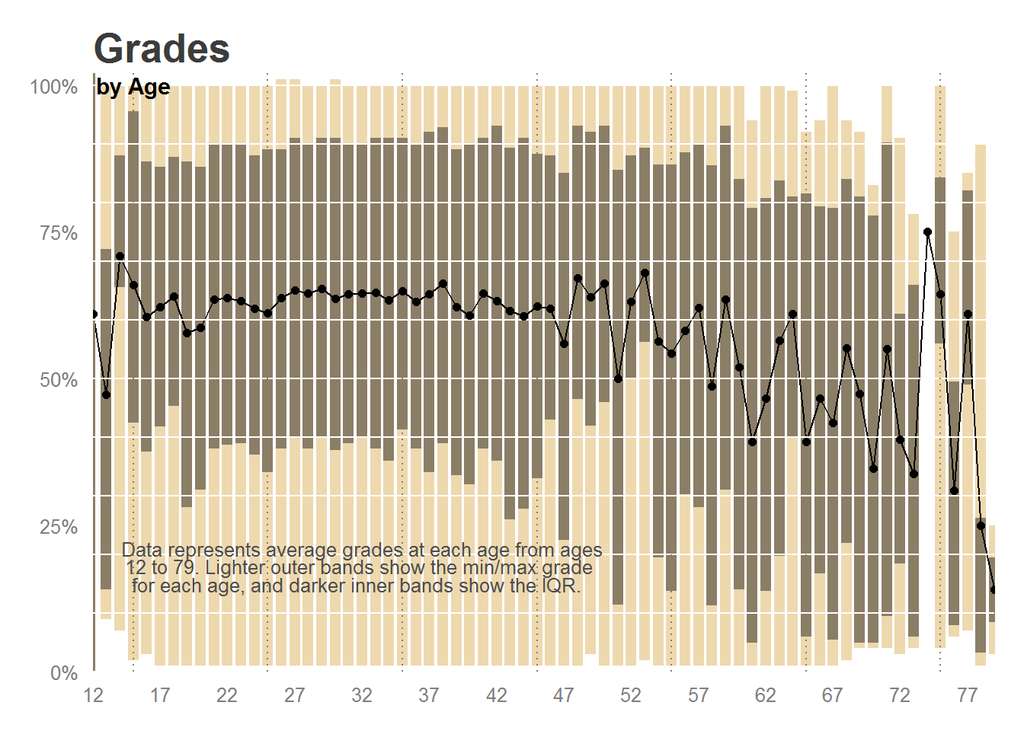

```r
age_grades <- mooc_data %>%
  filter(!is.na(grade),
         Active_User == "Active",
         Age > 5) %>%
  group_by(Age) %>%
  summarise(avg_grade = mean(grade),
            median_grade = median(grade),
            sd = sd(grade),
            lower = min(grade),
            upper = max(grade),
            quant.25 = quantile(grade, probs=0.25, na.rm=TRUE),
            quant.75 = quantile(grade, probs=0.75, na.rm=TRUE),
            n = n())

p <- ggplot(age_grades, aes(x=Age, y=avg_grade)) +
  theme(plot.background = element_blank(),
                panel.grid.minor = element_blank(),
                panel.grid.major = element_blank(),
                panel.border = element_blank(),
                panel.background = element_blank(),
                axis.ticks = element_blank(),
                axis.title = element_blank()) +
  geom_linerange(age_grades, mapping=aes(x=Age, ymin=lower, ymax=upper), colour = "wheat2", alpha=1, size=2.5) +
  geom_linerange(age_grades, mapping=aes(x=Age, ymin=quant.25, ymax=quant.75), colour = "wheat4", size=2.5) +
  geom_line(age_grades, mapping=aes(x=Age, y=avg_grade, group=1)) +
  geom_vline(xintercept = 12, colour = "wheat4", linetype=1, size=1, hjust=0) +
  geom_hline(yintercept=seq(0, 1, 0.1), color="white", linetype=1)

dottedAges <- seq(15, 75, 10)

p <- p + geom_vline(xintercept = dottedAges, color="wheat4", linetype=3, size=0.5)

p <- p + coord_cartesian(ylim = c(0,1.02)) +
  scale_y_continuous(labels=percent) +
  scale_x_continuous(breaks=seq(12, 82, 5), expand=c(0,0) ) +
  ggtitle("Grades") +
  theme(plot.title=element_text(face="bold",hjust=0,vjust=.8,color="#3C3C3C",size=20)) +
  annotate("text", x=15, y=1, label="by Age", size=4, fontface="bold") +
  annotate("text", x=32, y=.21,   label="Data represents average grades at each age from ages", size=3.5, color="gray30") +
    annotate("text", x=32, y=.18, label="12 to 79. Lighter outer bands show the min/max grade ", size=3.5, color="gray30") +
    annotate("text", x=32, y=.15, label="for each age, and darker inner bands show the IQR.  ", size=3.5, color="gray30") +
  geom_point()

p
```

Averages grades for the different levels of education for active users showed large bump for those who have a post-graduate degree.

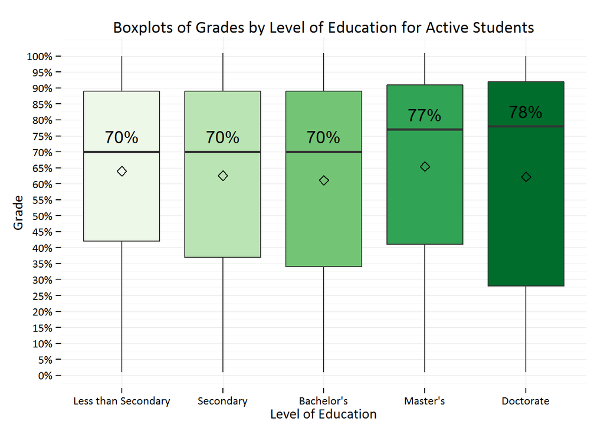

```r
ggplot(subset(mooc_data, Active_User == "Active" & !is.na(Level_of_Edu)), aes(x=Level_of_Edu, y=grade, fill=Level_of_Edu)) +
  geom_boxplot() +
  scale_y_continuous(breaks=seq(0, 1, .05), labels=percent) +
  scale_fill_brewer(type="seq", palette=5, name="Education Level", guide=FALSE) +
  theme_minimal() +
  stat_summary(fun.y=median, colour="black", geom="text", show_guide = FALSE, vjust=-0.7,
               aes( label=paste(round(..y.., 4)*100, "%", sep=""))) +
  stat_summary(fun.y=mean, colour="black", geom="point", show_guide = FALSE, vjust=-0.7, shape=23, size=3) +
  ggtitle("Boxplots of Grades by Level of Education for Active Students") +
  ylab("Grade") + xlab("Level of Education") +
  theme(text=element_text(family="Calibri"))
```

If we look at just those who earned a certificate, this progression in average grades by education level continues.

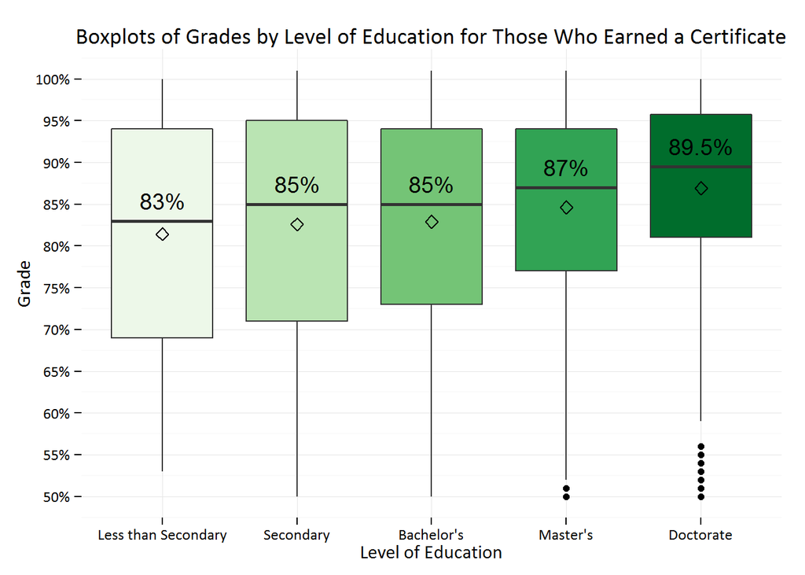

```r
ggplot(subset(mooc_data, certified == "Yes" & !is.na(Level_of_Edu)), aes(x=Level_of_Edu, y=grade, fill=Level_of_Edu)) +
  geom_boxplot() +
  scale_y_continuous(breaks=seq(0, 1, .05), labels=percent) +
  scale_fill_brewer(type="seq", palette=5, name="Education Level", guide=FALSE) +
  theme_minimal() +
  stat_summary(fun.y=median, colour="black", geom="text", show_guide = FALSE, vjust=-0.7,
               aes( label=paste(round(..y.., 4)*100, "%", sep=""))) +
  stat_summary(fun.y=mean, colour="black", geom="point", show_guide = FALSE, vjust=-0.7, shape=23, size=3) +
  ggtitle("Boxplots of Grades by Level of Education for Those Who Earned a Certificate") +
  ylab("Grade") + xlab("Level of Education") +
  theme(text=element_text(family="Calibri"))
```

And finally, grades for active users by country show Germany, Russian Federation, Portugal and Spain at the head of the class.

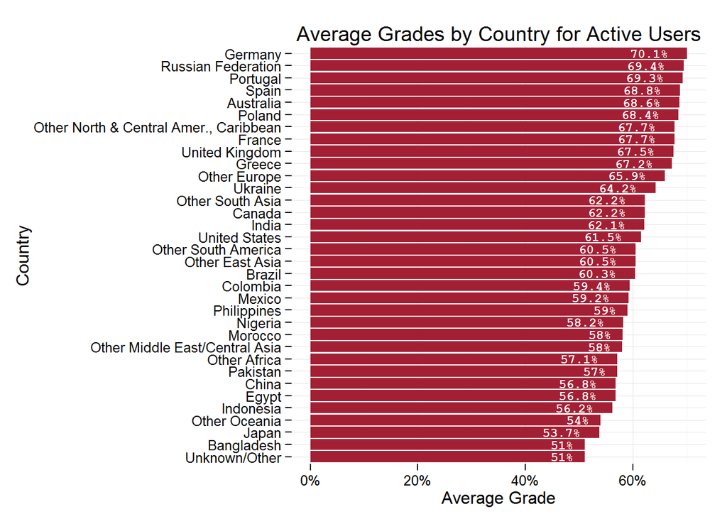

```r
country_grade <- mooc_data %>%
  filter(!is.na(grade),
         Active_User == "Active") %>%
  group_by(Country) %>%
  summarise(avg_grade = mean(grade))

ggplot(country_grade, aes(x=reorder(Country, avg_grade), y=avg_grade)) +
  geom_bar(stat="identity", fill="#A31F34") +
  coord_flip() +
  scale_y_continuous(labels = percent) +
  geom_text(aes(family="mono", fontface="bold", y=avg_grade,
                label=paste(round(avg_grade, 3)*100, "%", sep="")), color="white", size=3, hjust=1.5) +
  theme_minimal() +
  ggtitle("Average Grades by Country for Active Users") + ylab("Average Grade") + xlab("Country")
```

# Final Plots

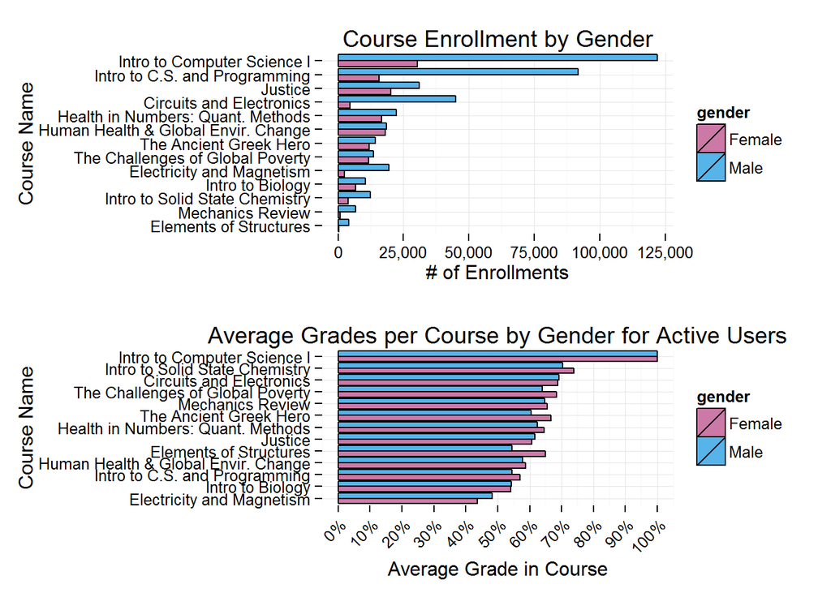

```r
grid.arrange(ge1, ge2, ncol=1)
```

[1] http://newsoffice.mit.edu/2014/mit-and-harvard-release-de-identified-learning-data-open-online-courses

[2] http://thedata.harvard.edu/dvn/dv/mxhx